# **Panorama da inflação**

Os principais índices de inflação do Brasil, apontam em dezembro de 2015 um avanço da inflação de em média **0.78%**. Com esse resultado, no ano a inflação acumula uma variação média positiva de **10.55%**, e em 12 meses uma variação média acumulada de **10.83%**.

|  | Variação mensal | Variação acumulada no ano | Variação acumulada em 12 meses |
| --- | --- | --- | --- |
| IPCA | 0.96% | 10.67% | 10.67% |
| INPC | 0.9% | 11.28% | 11.28% |
| IGP-M | 0.49% | 9.7% | 10.54% |
| IGP-DI | 0.44% | 9.97% | 10.7% |
| IPA | 0.33% | 0.11% | 0.11% |
| IPC | 0.88% | 8.65% | 10.53% |
| INCC | 0.1% | 6.5% | 7.48% |

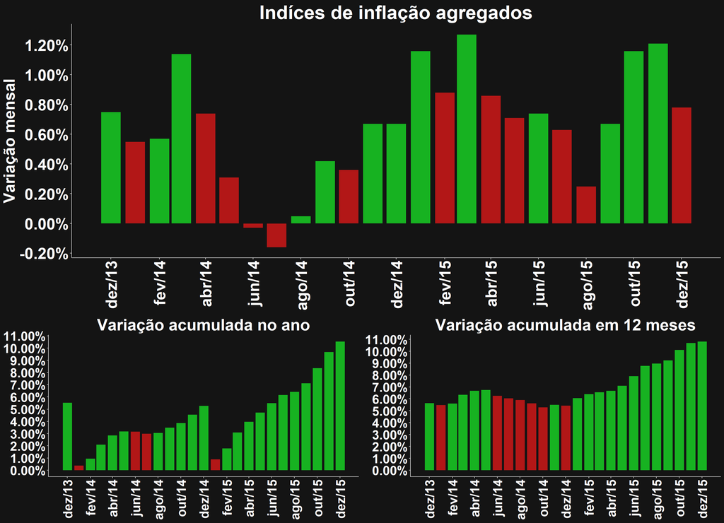

Índices selecionados para a média: IPCA, INPC e IGP-M.

# IPCA

O Indíce de Preços ao Consumidor Amplo (IPCA) variou 0.96% em dezembro, valor superior ao mesmo período do ano anterior quando apresentou uma taxa de 0.78%. Com esse resultado o indíce acumula no ano uma variação positiva de 10.67%, e em 12 meses uma variação positiva de 10.67%.

|  | 12/2014 | 11/2015 | 12/2015 |
| --- | --- | --- | --- |
| Variação mensal | 0.78% | 1.01% | 0.96% |
| Variação acumulada no ano | 6.41% | 9.62% | 10.67% |
| Variação acumulada em 12 meses | 6.41% | 10.48% | 10.67% |

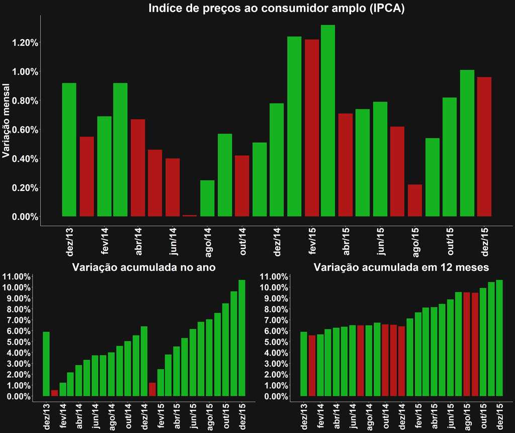

|  | Variação mensal | Variação acumulada no ano | Peso mensal |
| --- | --- | --- | --- |
| Alimentação e bebidas | 1.5% | 12.01% | 25.1% |
| Habitação | 0.49% | 18.34% | 15.81% |
| Artigos de residência | 0.46% | 5.38% | 4.3% |
| Vestuário | 1.15% | 4.47% | 6.11% |
| Transportes | 1.36% | 10.17% | 18.37% |
| Saúde e cuidados pessoais | 0.7% | 9.2% | 11.17% |
| Despesas pessoais | 0.57% | 9.51% | 10.68% |
| Educação | 0.22% | 9.25% | 4.56% |
| Comunicação | 0.43% | 2.1% | 3.89% |

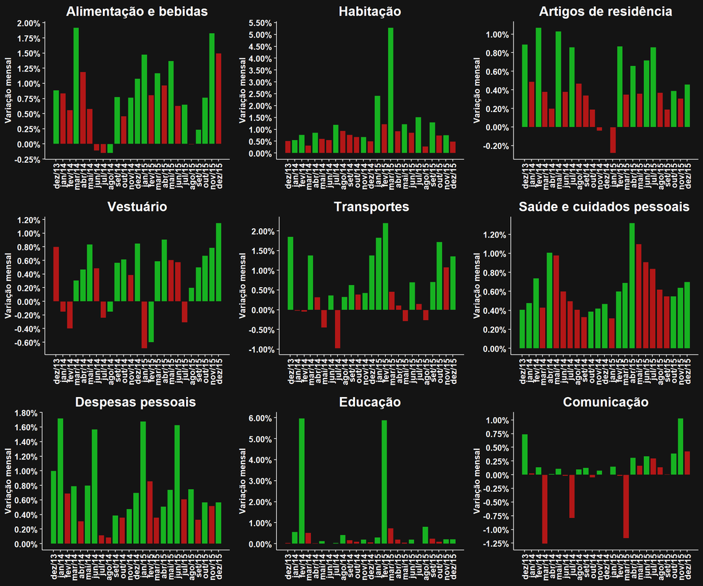

A nível de sub-itens os que mais influenciaram positivamente no resultado em relação ao seu peso foram Passagem aérea (37.07%%) e Gasolina (1.26%%), e negativamente Automóvel novo (-0.27%%) e Uva (-6.04%%).

|  | Variação mensal | Variação acumulada no ano | Peso mensal |
| --- | --- | --- | --- |
| Passagem aérea | 37.07% | -15.22% | 0.38% |
| Gasolina | 1.26% | 20.1% | 4.07% |
| Plano de saúde | 1.06% | 12.16% | 3.31% |
| Refeição | 0.88% | 9.7% | 5.16% |

|  | Variação mensal | Variação acumulada no ano | Peso mensal |
| --- | --- | --- | --- |
| Automóvel novo | -0.27% | 4.84% | 2.99% |
| Móvel para quarto | -0.61% | 5.36% | 0.5% |
| Iogurte e bebidas lácteas | -1.97% | 6.86% | 0.22% |
| Uva | -6.04% | 8.3% | 0.09% |

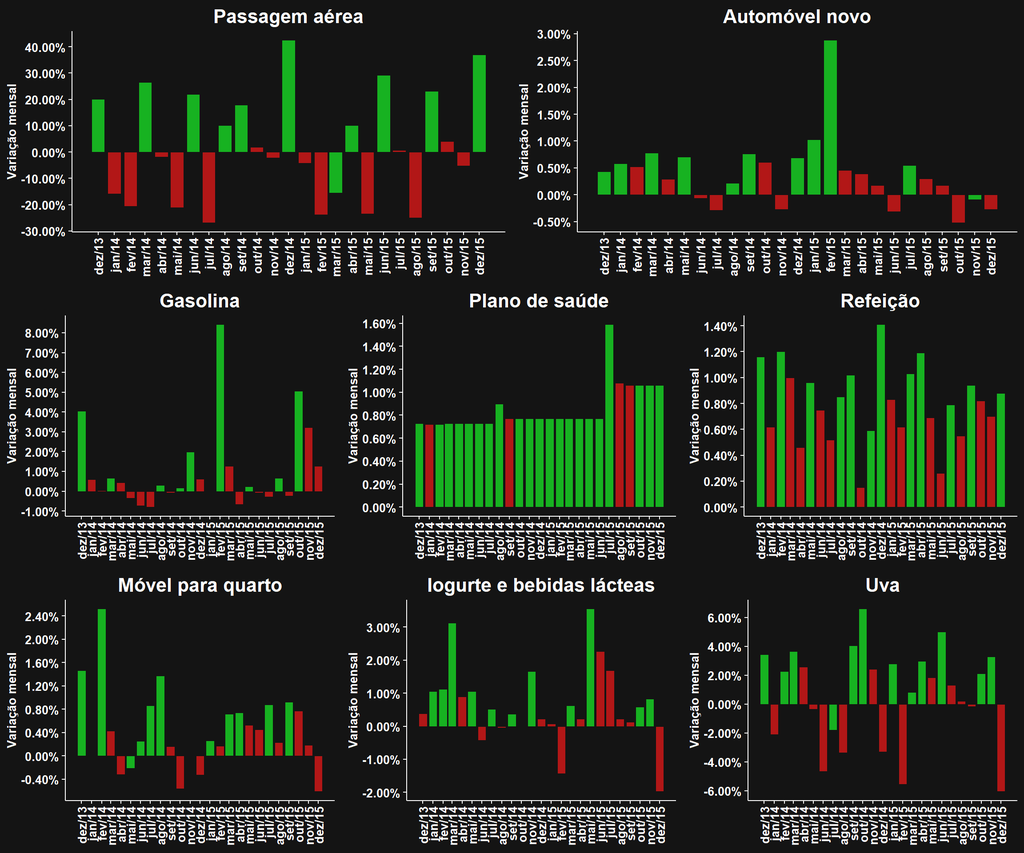

# INPC

O Indíce Nacional de Preços ao Consumidor (INPC) variou 0.9% em dezembro, valor superior ao mesmo período do ano anterior quando apresentou uma taxa de 0.62%. Com esse resultado o indíce acumula no ano uma variação positiva de 11.28%, e em 12 meses uma variação positiva de 11.28%.

|  | 12/2014 | 11/2015 | 12/2015 |
| --- | --- | --- | --- |
| Variação mensal | 0.62% | 1.11% | 0.9% |
| Variação acumulada no ano | 6.23% | 10.28% | 11.28% |
| Variação acumulada em 12 meses | 6.23% | 10.97% | 11.28% |

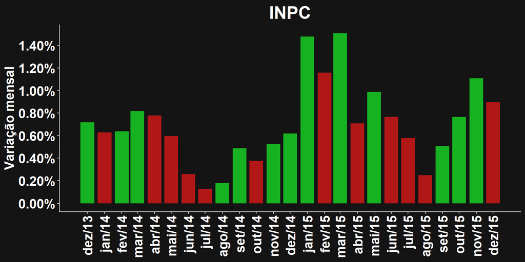

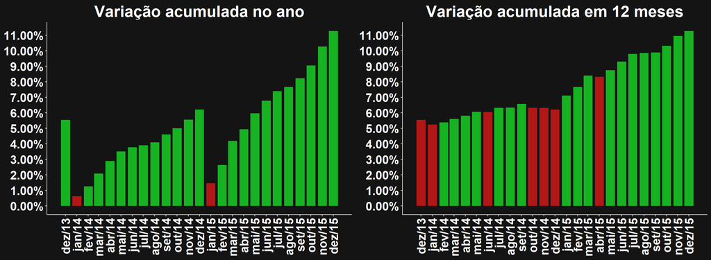

# IGP-M

|  | 12/2014 | 11/2015 | 12/2015 |
| --- | --- | --- | --- |
| Variação mensal | 0.62% | 1.52% | 0.49% |
| Variação acumulada no ano | 3.19% | 9.17% | 9.7% |
| Variação acumulada em 12 meses | 3.69% | 10.69% | 10.54% |

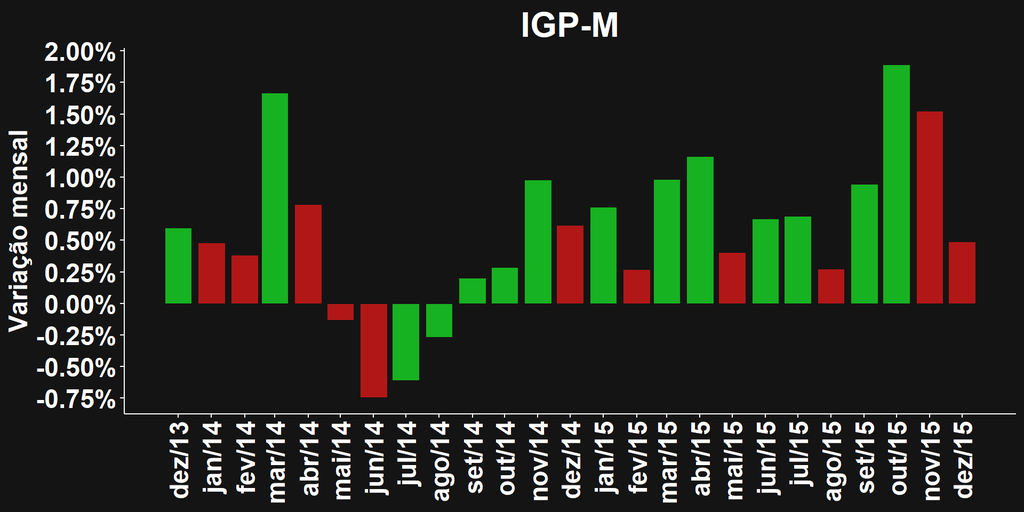

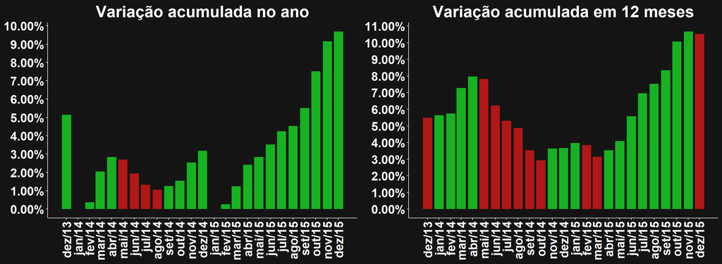

# IGP-DI

O Indíce Geral de Preços - Disponibilidade Interna (IGP-DI) variou 0.44% em dezembro, valor superior ao mesmo período do ano anterior quando apresentou uma taxa de 0.38%. Com esse resultado o indíce acumula no ano uma variação positiva de 9.97%, e em 12 meses uma variação positiva de 10.7%.

|  | 12/2014 | 11/2015 | 12/2015 |
| --- | --- | --- | --- |
| Variação mensal | 0.38% | 1.19% | 0.44% |
| Variação acumulada no ano | 3.37% | 9.48% | 9.97% |
| Variação acumulada em 12 meses | 3.78% | 10.64% | 10.7% |

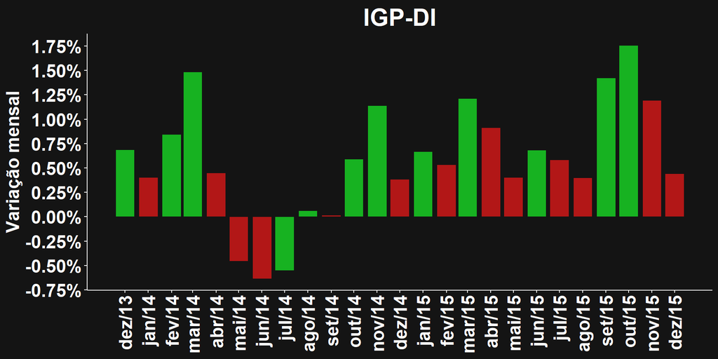

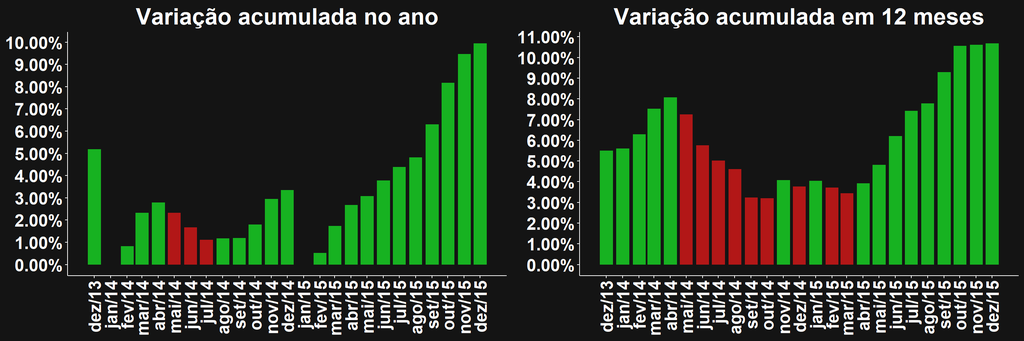

|  | 12/2014 | 11/2015 | 12/2015 |
| --- | --- | --- | --- |
| Variação mensal | 0.3% | 1.41% | 0.33% |
| Variação acumulada no ano | 0.02% | 0.11% | 0.11% |
| Variação acumulada em 12 meses | 0.02% | 0.11% | 0.11% |

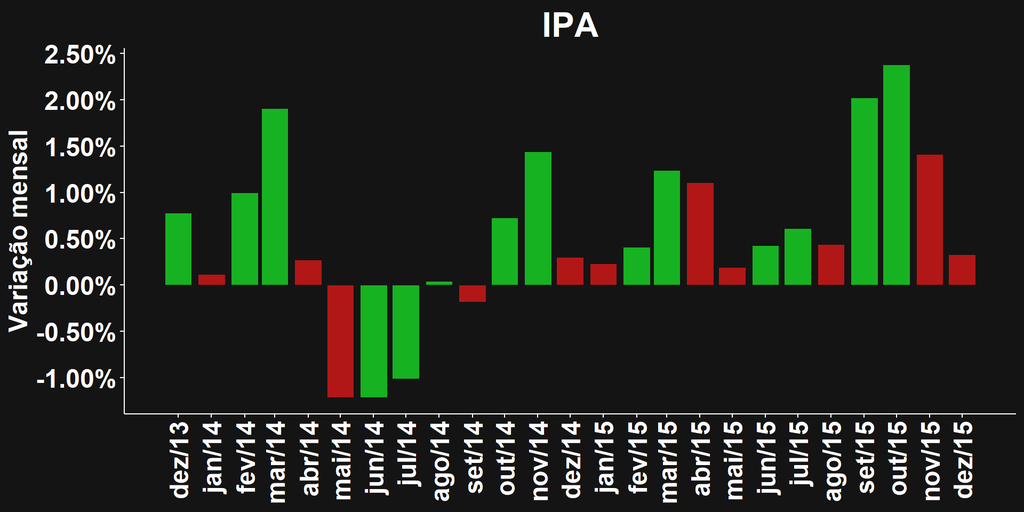

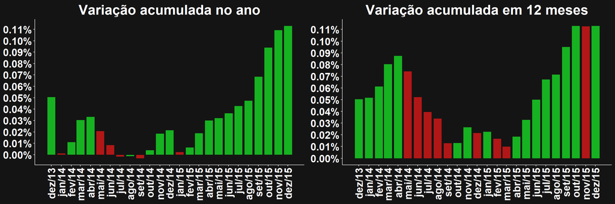

O Indíce de Preços ao Consumidor (IPC), integrante do IGP-DI com peso de 30%, apresentou variação de 0.88% em dezembro, valor superior ao mesmo período do ano anterior quando apresentou uma taxa de 0.75%. Com esse resultado o indíce acumula no ano uma variação positiva de 8.65%, e em 12 meses uma variação positiva de 10.53%.

|  | 12/2014 | 11/2015 | 12/2015 |
| --- | --- | --- | --- |
| Variação mensal | 0.75% | 1% | 0.88% |
| Variação acumulada no ano | 5.82% | 7.7% | 8.65% |
| Variação acumulada em 12 meses | 6.87% | 10.39% | 10.53% |

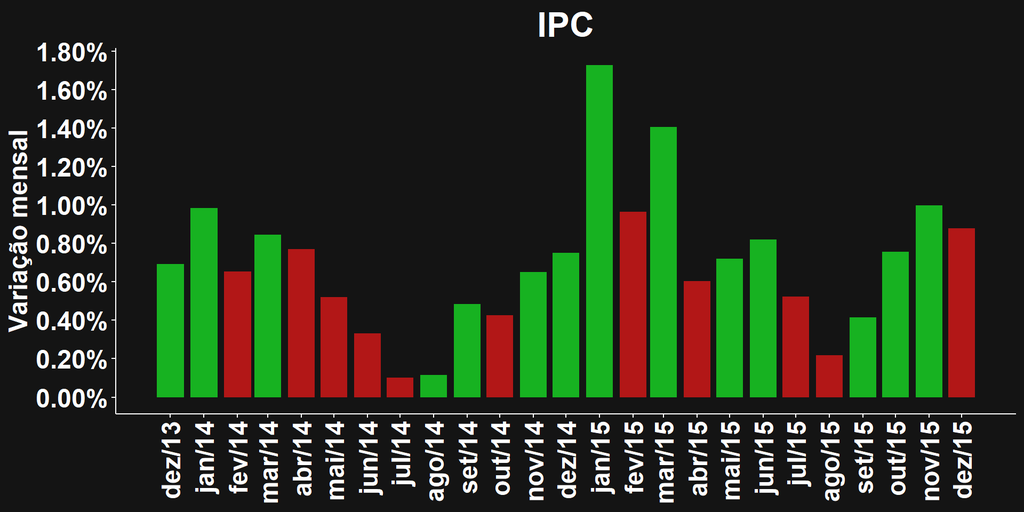

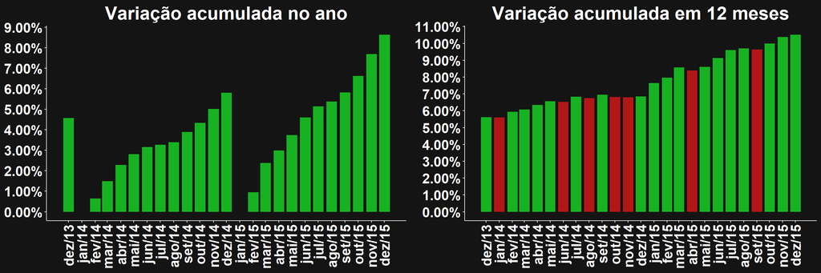

O Indíce Nacional de Custos de Construção (INCC), integrante do IGP-DI com peso de 10%, apresentou variação de 0.1% em dezembro, valor superior ao mesmo período do ano anterior quando apresentou uma taxa de 0.08%. Com esse resultado o indíce acumula no ano uma variação positiva de 6.5%, e em 12 meses uma variação positiva de 7.48%.

|  | 12/2014 | 11/2015 | 12/2015 |
| --- | --- | --- | --- |
| Variação mensal | 0.08% | 0.34% | 0.1% |
| Variação acumulada no ano | 6.02% | 6.39% | 6.5% |
| Variação acumulada em 12 meses | 6.95% | 7.46% | 7.48% |

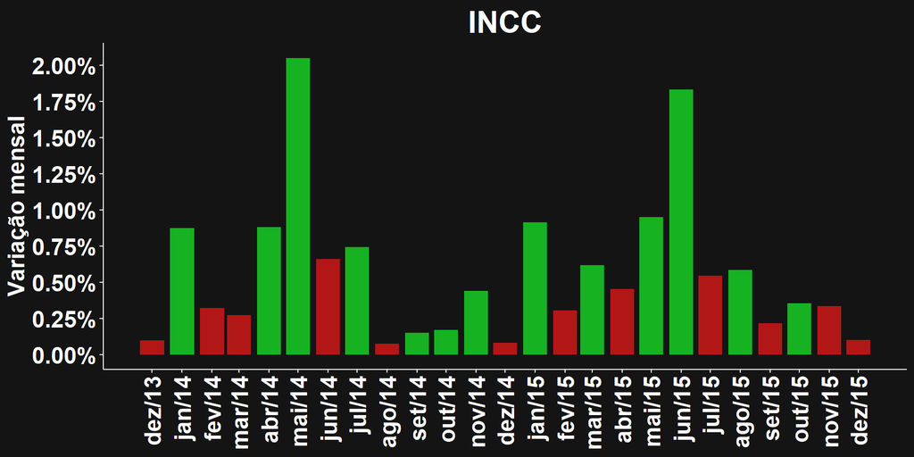

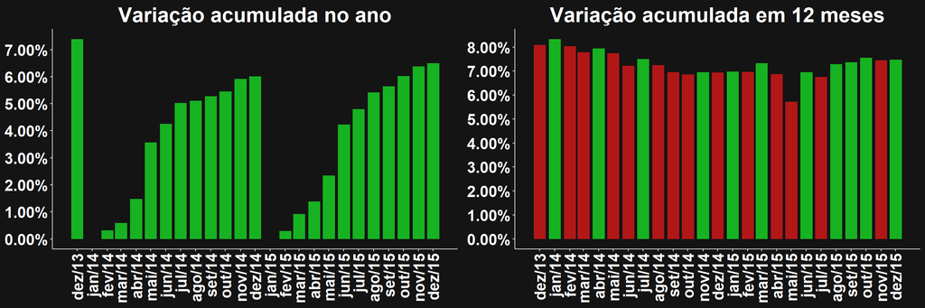

# Estatísticas

As estatísticas descritivas a seguir são feitas com base nos últimos 48 meses, e tem como objetivo possibilitar a avaliação do resultado observado em comparação aos períodos anteriores.

|  | Minimo | 1 Quartil | Mediana | Media | 3 Quartil | Maximo | Desvio Padrão |
| --- | --- | --- | --- | --- | --- | --- | --- |
| IPCA | 0.01% | 0.41% | 0.56% | 0.58% | 0.75% | 1.32% | 0.29% |
| INPC | -0.13% | 0.39% | 0.58% | 0.59% | 0.72% | 1.51% | 0.32% |
| IGP-M | -0.74% | 0.24% | 0.48% | 0.56% | 0.88% | 1.89% | 0.56% |
| IGP-DI | -0.63% | 0.29% | 0.55% | 0.57% | 0.89% | 1.76% | 0.54% |
| IPA | -1.21% | 0.11% | 0.44% | 0.56% | 1.03% | 2.38% | 0.82% |
| IPC | -0.17% | 0.35% | 0.53% | 0.58% | 0.75% | 1.73% | 0.34% |
| INCC | 0.08% | 0.27% | 0.47% | 0.6% | 0.74% | 2.25% | 0.5% |

Levando em consideração o desvio padrão de cada indíce, proporcionalmente os que mais se afastaram da média foram o IPCA, o INCC e o INPC.

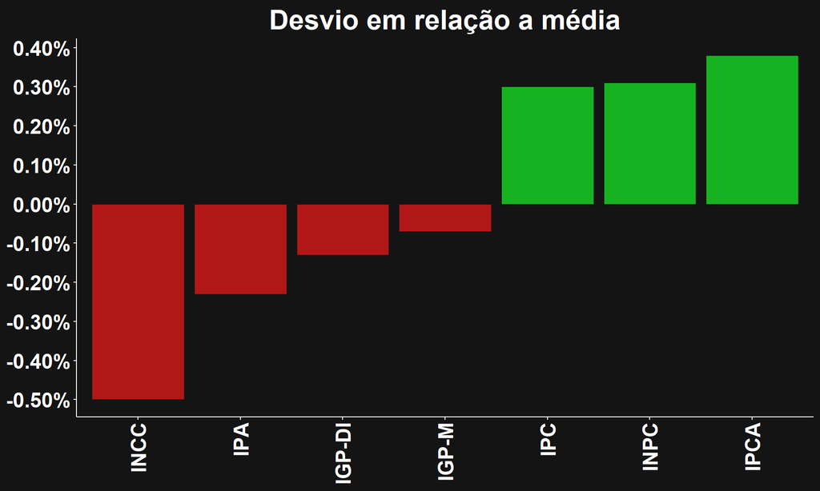

**João Victor Gomes**  
**jvg.santana@gmail.com**  
**[linkedin.com/in/jvictorgomes](https://www.linkedin.com/in/jvictorgomes/)**